# COPDGene African-Americans & QQ plots

Andrey Ziyatdinov & Hugues Aschard

July 19, 2017 Meeting at Channing

## Background

- 3.3K African-Americans from the COPDGene project
- 7 quantitative & 1 binary outcomes
- 37K clean and long (>10kb) local ancestry segments

Association models

- marginal: $y \sim a_g + a_l$
- interaction: $y \sim a_g + a_l + x_e + a_g * x_e + a_e * x_e$
  - binary exposures
    - `SmokCigNow`
    - `CigPerDayNow > 15`
    - `CompletedSchool > 2`

## First QQ plots (March 2017)

[figure not shown]

## We explored two strategies to fix QQ plots

1. Smoking covariates

| Initial Model | Current model |
| --- | --- |
| `ATS_PackYears` | `Duration_Smoking + log_CigPerDaySmokAvg` |
| `SmokCigNow` (2 groups) | `CigPerDaySmokNow` (3 groups) |
|  | `SmokCigarNow` |

2. Models to test for association

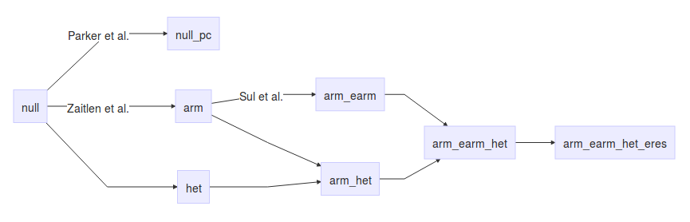

## Methods applied

1. Ancestry Relatedness Matrix (ARM) (Zaitlen et al. 2014)
2. Another (**E**ARM) for ancestry-by-**e**xposure component (Sul et al. 2016)
3. Modeling heteroskedasticity
4. Selection of smoking covariates
5. Automate and speed up computation developing R packages
   - copdgene to read/process data
   - bigcov for big data covariances
   - matlm for fast association tests
   - lme4qtl for flexible mixed models

| trait | h2_acs | h2 |
| --- | --- | --- |
| FEV1_FVC_utah | 0.0057 |  |
| FEV1pp_utah | 0.0105 |  |
| FEV1_utah | 0.0104 |  |
| FVCpp_utah | 0.0078 |  |
| FVC_utah | 0.0079 |  |
| log_pctEmph_Slicer | 0.0076 |  |
| TLCpp_race_adjusted | 0.0131 |  |

$h^2_{acs} = 2 F_{STC} \theta (1 - \theta) h^2$ (Zaitlen et al. 2014), where

- $F_{STC}$ measures frequency differences between populations
- $\theta$ is the genome-wide ancestry proportion, i.e. global ancestry $a_g$

Example: on simulated data on Figure 1 (Zaitlen et al. 2014) $h^2_{acs}$ 0.032 (s.e. 0.007) corresponds to $h^2$ 0.83 (s.e. 0.18) (simulated parameters $F_{STC} = 0.08$ and $\theta = 0.5$)

$h^2$ for FEV1/FVC in the UK Biobank sample of 84K: ~80% (Ge et al. 2017)

## Covariance Matrices & Association model

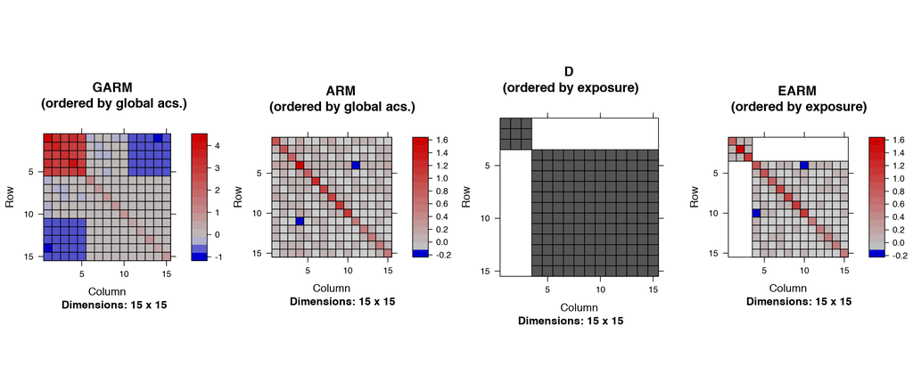

$y \sim a_g + a_{l_i} + x_e + a_g * x_e + a_{l_i} * x_e + g + g_{int} + e$ (Sul et al. 2016)

- $g \sim \mathcal{N}(0, \sigma^2_g ARM)$
- $g_{int} \sim \mathcal{N}(0, \sigma^2_{g_{int}} EARM)$
- $e \sim \mathcal{N}(0, \sigma^2_e I)$

## Heteroskedasticity due to SmokCigNow

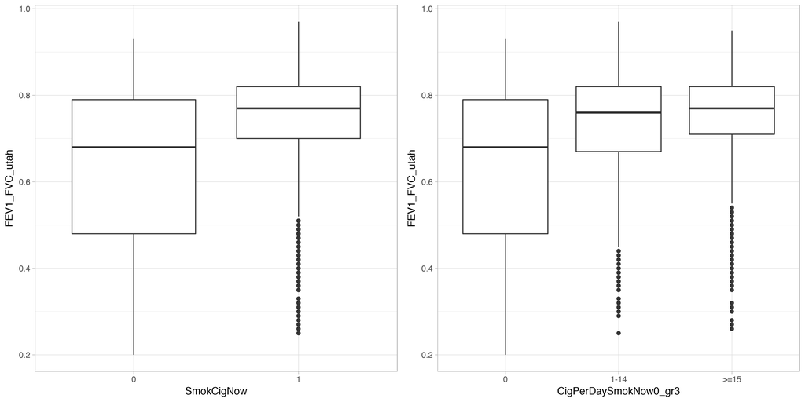

Unbalanced groups by `SmokCigNow` / `CigPerDaySmokNow`:

- **0**: 657 (20%)
- **1-14**: 1,261 (38%)
- **>=15**: 1382 (42%)

## `het_arm`: QQ plots (marginal)

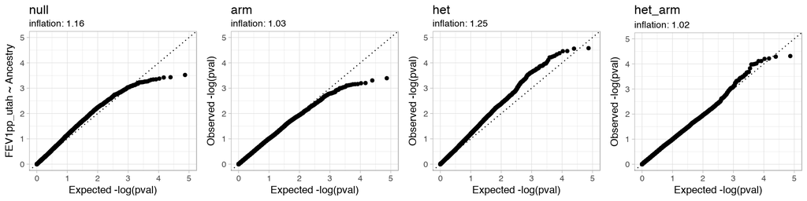

| Model | Purpose | Inflation? |
| --- | --- | --- |
| `arm` | Population stratification | No |
| `het` | More residual variance explained | Yes |
| `het_arm` | Population stratification + More variance explained | No |

Improved power in comparison with (Parker et al. 2014)?

## `het_arm`: QQ plots (interaction)

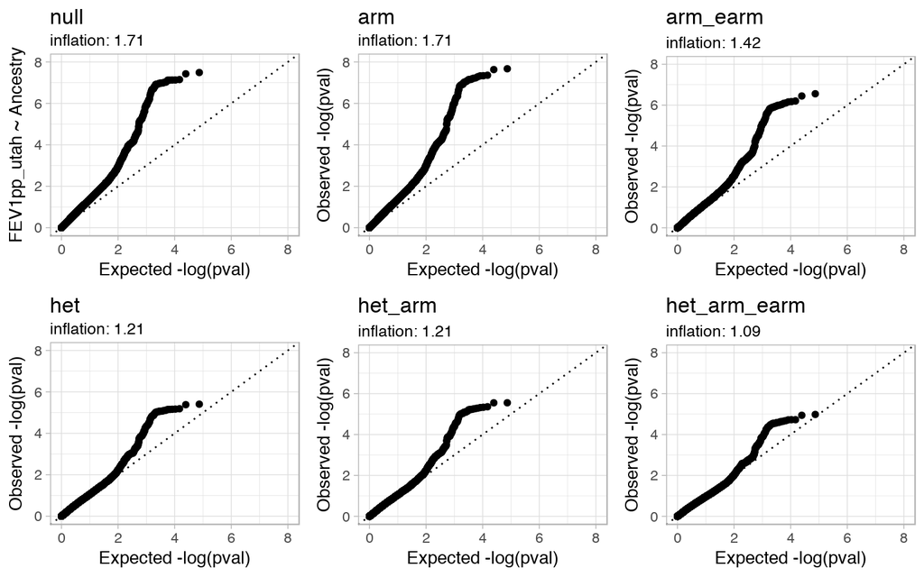

## Results: *Clean* QQ plots (marginal)

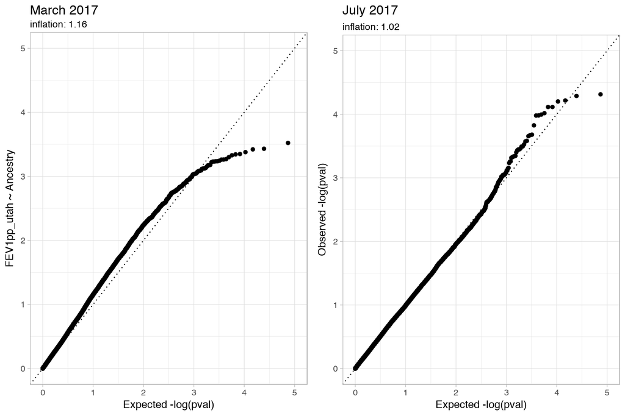

## Results: *Nearly Clean* QQ plots (interaction)

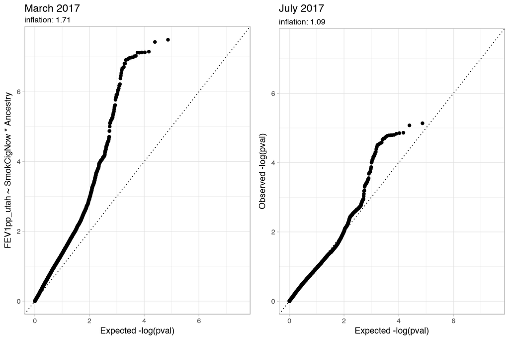

## Results: Genes (Bonferroni `0.05 / 37K =` `1.4e-06`)

Ancestry segment: 11:12,332,105 - 12,394,102  
Genes: **PARVA**, MICAL2, MICALCL, RASSF10, TEAD1

| Trait | Exposure | z-score | p-value |
| --- | --- | --- | --- |
| FEV1pp | SmokCigNow | 4.5 | 7.3e-06 |
| FEV1_FVC | SmokCigNow | 3.9 | 1.1e-04 |
| FEV1 | SmokCigNow | 3.8 | 1.4e-04 |

Ancestry segment: 2:238,819,792 - 238,904,351  
Genes: **TWIST2**, HDAC4, MIR4440, MIR4441

| Trait | Exposure | z-score | p-value |
| --- | --- | --- | --- |
| FEV1 | SmokCigNow0_15 | 4.2 | 2.6e-05 |
| FEV1pp | SmokCigNow0_15 | 4.1 | 4.9e-05 |
| FVC | SmokCigNow0_15 | 4.0 | 6.9e-05 |
| FVCpp | SmokCigNow0_15 | 3.7 | 2.5e-04 |

## Future work

Phenotypes & other type of data

- Other binary or multi-level exposures to test
- SNPs, methylation data, …

Association models

- Joint test for multiple phenotypes
- Joint test for marginal and interaction terms
- Fine-mapping by testing SNPs in gene regions as in (Parker et al. 2014)
- Mixed models for binary outcome
- Squared terms for smoking covariates
- The effective number of tests (Bonferroni is a killer)

Other analysis

- Heritability explained by GxE as in (Zaitlen et al. 2014) or in the whole COPDGene sample

Computation

- matlm is now only for binary exposures
- lme4qtl is slow for dense covariances

# Extra slides

## Marginal effects of global ancestry and SmokCigNow (REML, model `het`, `SmokCigNow0_15` included)

| trait | term | Zscore | pval |
| --- | --- | --- | --- |
| FEV1_FVC_utah | acs_global | -0.4 | 6.9e-01 |
| FEV1pp_utah | acs_global | -4.9 | 8.6e-07 |
| FEV1_utah | acs_global | -4.8 | 1.9e-06 |
| FVCpp_utah | acs_global | -6.3 | 3.6e-10 |
| FVC_utah | acs_global | -5.9 | 3.5e-09 |
| log_pctEmph_Slicer | acs_global | -1.0 | 3.1e-01 |
| TLCpp_race_adjusted | acs_global | -6.5 | 6.7e-11 |

| trait | term | Zscore | pval |
| --- | --- | --- | --- |
| FEV1_FVC_utah | SmokCigNow1 | 7.3 | 2.7e-13 |
| FEV1pp_utah | SmokCigNow1 | 9.1 | 8.0e-20 |
| FEV1_utah | SmokCigNow1 | 8.5 | 2.8e-17 |
| FVCpp_utah | SmokCigNow1 | 7.6 | 4.3e-14 |
| FVC_utah | SmokCigNow1 | 7.5 | 8.5e-14 |
| log_pctEmph_Slicer | SmokCigNow1 | -7.8 | 9.0e-15 |
| TLCpp_race_adjusted | SmokCigNow1 | -1.4 | 1.5e-01 |

## Interaction effects (REML, model `het`, `SmokCigNow0_15` included)

| trait | term | Zscore | pval |
| --- | --- | --- | --- |
| FEV1_FVC_utah | acs_global | -1.23 | 0.2169 |
| FEV1pp_utah | acs_global | -2.37 | 0.0176 |
| FEV1_utah | acs_global | -1.96 | 0.0496 |
| FVCpp_utah | acs_global | -2.46 | 0.0138 |
| FVC_utah | acs_global | -1.89 | 0.0587 |
| log_pctEmph_Slicer | acs_global | 0.48 | 0.6295 |
| TLCpp_race_adjusted | acs_global | -2.67 | 0.0075 |

| trait | term | Zscore | pval |
| --- | --- | --- | --- |
| FEV1_FVC_utah | SmokCigNow1 | 0.097 | 0.923 |
| FEV1pp_utah | SmokCigNow1 | 1.180 | 0.238 |
| FEV1_utah | SmokCigNow1 | 1.566 | 0.117 |
| FVCpp_utah | SmokCigNow1 | 1.663 | 0.096 |
| FVC_utah | SmokCigNow1 | 2.265 | 0.024 |
| log_pctEmph_Slicer | SmokCigNow1 | -0.375 | 0.708 |
| TLCpp_race_adjusted | SmokCigNow1 | 0.043 | 0.965 |

| trait | term | Zscore | pval |
| --- | --- | --- | --- |
| FEV1_FVC_utah | SmokCigNow1:acs_global | 1.4 | 0.2 |
| FEV1pp_utah | SmokCigNow1:acs_global | 0.4 | 0.7 |
| FEV1_utah | SmokCigNow1:acs_global | -0.2 | 0.8 |
| FVCpp_utah | SmokCigNow1:acs_global | -0.4 | 0.7 |
| FVC_utah | SmokCigNow1:acs_global | -1.1 | 0.3 |
| log_pctEmph_Slicer | SmokCigNow1:acs_global | -1.2 | 0.2 |
| TLCpp_race_adjusted | SmokCigNow1:acs_global | -0.3 | 0.8 |

## References

Ge et al. 2017. “Phenome-Wide Heritability Analysis of the Uk Biobank.” *PLoS Genetics* 13 (4). Public Library of Science: e1006711.

Parker et al. 2014. “Admixture mapping identifies a quantitative trait locus associated with FEV1/FVC in the COPDGene Study.” *Genetic Epidemiology* 38 (7): 652–59. doi:10.1002/gepi.21847.

Sul et al. 2016. “Accounting for Population Structure in Gene-by-Environment Interactions in Genome-Wide Association Studies Using Mixed Models.” *PLoS Genetics* 12 (3): e1005849. doi:10.1371/journal.pgen.1005849.

Zaitlen et al. 2014. “Leveraging population admixture to characterize the heritability of complex traits.” *Nature Genetics* 46 (12). Nature Publishing Group: 1356–62. doi:10.1038/ng.3139.